# Country_Happiness

```python
import numpy as np
import pandas as pd
import matplotlib.pyplot as plt
%matplotlib notebook

data2015 = pd.read_csv('2015.csv')
data2016 = pd.read_csv('2016.csv')
data2017 = pd.read_csv('2017.csv')
```

```python
data2015.head()
```

|  | Country | Region | Happiness Rank | Happiness Score | Standard Error | Economy (GDP per Capita) | Family | Health (Life Expectancy) | Freedom | Trust (Government Corruption) | Generosity | Dystopia Residual |
| --- | --- | --- | --- | --- | --- | --- | --- | --- | --- | --- | --- | --- |
| 0 | Switzerland | Western Europe | 1 | 7.587 | 0.03411 | 1.39651 | 1.34951 | 0.94143 | 0.66557 | 0.41978 | 0.29678 | 2.51738 |
| 1 | Iceland | Western Europe | 2 | 7.561 | 0.04884 | 1.30232 | 1.40223 | 0.94784 | 0.62877 | 0.14145 | 0.43630 | 2.70201 |
| 2 | Denmark | Western Europe | 3 | 7.527 | 0.03328 | 1.32548 | 1.36058 | 0.87464 | 0.64938 | 0.48357 | 0.34139 | 2.49204 |
| 3 | Norway | Western Europe | 4 | 7.522 | 0.03880 | 1.45900 | 1.33095 | 0.88521 | 0.66973 | 0.36503 | 0.34699 | 2.46531 |
| 4 | Canada | North America | 5 | 7.427 | 0.03553 | 1.32629 | 1.32261 | 0.90563 | 0.63297 | 0.32957 | 0.45811 | 2.45176 |

## How has the happiness score of the top 5 countries changed over the period 2015-2017?

```python
data2015.set_index(data2015['Country'], inplace = True)
data2016.set_index(data2016['Country'], inplace = True)
data2017.set_index(data2017['Country'], inplace = True)
```

```python
data2017.loc['Switzerland']['Happiness.Score']
```

```
7.4939999580383301
```

```python
X1 = (data2015.loc['Switzerland']['Happiness Score'], data2016.loc['Switzerland']['Happiness Score'], data2017.loc['Switzerland']['Happiness.Score'])
X2 = (data2015.loc['Iceland']['Happiness Score'], data2016.loc['Iceland']['Happiness Score'], data2017.loc['Iceland']['Happiness.Score'])
X3 = (data2015.loc['Denmark']['Happiness Score'], data2016.loc['Denmark']['Happiness Score'], data2017.loc['Denmark']['Happiness.Score'])
X4 = (data2015.loc['Norway']['Happiness Score'], data2016.loc['Norway']['Happiness Score'], data2017.loc['Norway']['Happiness.Score'])
X5 = (data2015.loc['Canada']['Happiness Score'], data2016.loc['Canada']['Happiness Score'], data2017.loc['Canada']['Happiness.Score'])

X1, X2, X3, X4, X5
```

```
((7.5870000000000006, 7.5089999999999995, 7.4939999580383301),
 (7.5609999999999999, 7.5010000000000003, 7.5040001869201696),
 (7.5270000000000001, 7.5259999999999998, 7.5219998359680202),
 (7.5220000000000002, 7.4979999999999993, 7.5370001792907688),
 (7.4270000000000005, 7.4039999999999999, 7.31599998474121))
```

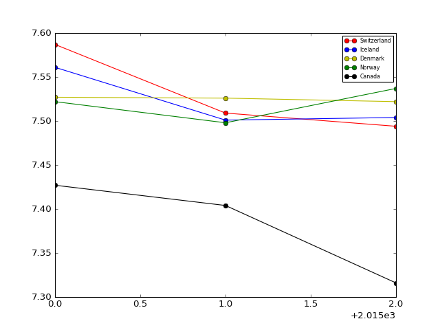

```python
plt.figure()
axes = plt.gca()
axes.set_ylim([7.3, 7.6])
xvals = ['2015', '2016', '2017']

plt.plot(xvals, X1, 'or-')

plt.plot(xvals, X2, 'ob-')

plt.plot(xvals, X3, 'oy-')

plt.plot(xvals, X4, 'og-')

plt.plot(xvals, X5, 'ok-')

plt.legend(['Switzerland', 'Iceland', 'Denmark', 'Norway', 'Canada'], prop={'size':7})
plt.legend(prop={'size':2})
```

## Observations

Overall, the trends have been negative, with most countries' Happiness Score dropping by small margins.

Norway has risen from rank 4 to 1 after a brief dip in 2016.

Denmark's Happiness Score remained roughly the same yet its rank appreciated from 3 to 2.

Switzerland saw its Happiness Score drop from ~7.58 to ~7.49.

## What about the bottom 5 countries?

```python
data2015['Country'][-5:]
```

```
Country
Rwanda      Rwanda
Benin        Benin
Syria        Syria
Burundi    Burundi
Togo          Togo
Name: Country, dtype: object
```

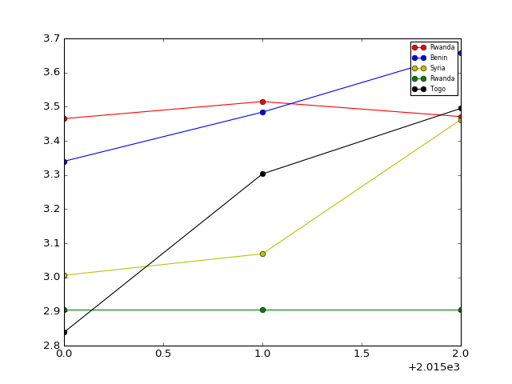

```python
X1 = (data2015.loc['Rwanda']['Happiness Score'], data2016.loc['Rwanda']['Happiness Score'], data2017.loc['Rwanda']['Happiness.Score'])
X2 = (data2015.loc['Benin']['Happiness Score'], data2016.loc['Benin']['Happiness Score'], data2017.loc['Benin']['Happiness.Score'])
X3 = (data2015.loc['Syria']['Happiness Score'], data2016.loc['Syria']['Happiness Score'], data2017.loc['Syria']['Happiness.Score'])
X4 = (data2015.loc['Burundi']['Happiness Score'], data2016.loc['Burundi']['Happiness Score'], data2017.loc['Burundi']['Happiness.Score'])
X5 = (data2015.loc['Togo']['Happiness Score'], data2016.loc['Togo']['Happiness Score'], data2017.loc['Togo']['Happiness.Score'])

plt.figure()
axes = plt.gca()
#axes.set_ylim([7.3, 7.6])
xvals = ['2015', '2016', '2017']

plt.plot(xvals, X1, 'or-')

plt.plot(xvals, X2, 'ob-')

plt.plot(xvals, X3, 'oy-')

plt.plot(xvals, X4, 'og-')

plt.plot(xvals, X5, 'ok-')

plt.legend(['Rwanda', 'Benin', 'Syria', 'Rwanda', 'Togo'], prop={'size':7})
plt.legend(prop={'size':2})
```

## Observations

It seems that the bottom 5 countries have by and large shown progress in their Happiness Score.

## Let us take a closer look at the bottom most country in the list: Togo

```python
data2015['Country'][-1:]
```

```
Country
Togo    Togo
Name: Country, dtype: object
```

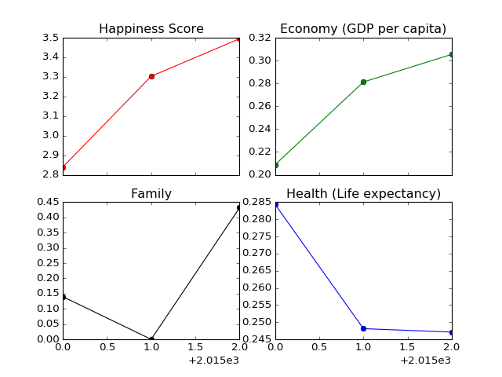

```python
X6 = (data2015.loc['Togo']['Happiness Score'], data2016.loc['Togo']['Happiness Score'], data2017.loc['Togo']['Happiness.Score'])
X7 = (data2015.loc['Togo']['Economy (GDP per Capita)'], data2016.loc['Togo']['Economy (GDP per Capita)'], data2017.loc['Togo']['Economy..GDP.per.Capita.'])
X8 = (data2015.loc['Togo']['Family'], data2016.loc['Togo']['Family'], data2017.loc['Togo']['Family'])
X9 = (data2015.loc['Togo']['Health (Life Expectancy)'], data2016.loc['Togo']['Health (Life Expectancy)'], data2017.loc['Togo']['Health..Life.Expectancy.'])

fig, ((ax1, ax2), (ax3, ax4)) = plt.subplots(2, 2, sharex=True, sharey=False)

#Happiness Score
ax1.plot(xvals, X6, 'or-')
ax1.set_title('Happiness Score')
#Economy
ax2.plot(xvals, X7, 'og-')
ax2.set_title('Economy (GDP per capita)')
#Family
ax3.plot(xvals, X8, 'ok-')
ax3.set_title('Family')
#Health
ax4.plot(xvals, X9, 'ob-')
ax4.set_title('Health (Life expectancy)')
```

## Observations

Happiness Score, Economy and Family present a hopeful picture of Togo's progress. However the country's Life Expectancy has deteriorated. This index seems at odds with the former three.

## General Distribution of Life Expectancy

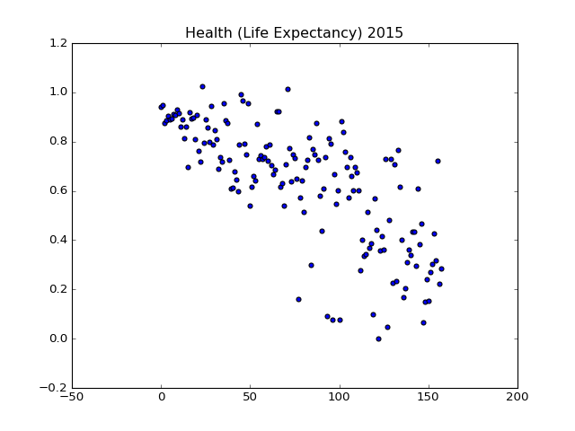

```python
x = range(158)
y = data2015['Health (Life Expectancy)']
plt.figure()
plt.scatter(x, y)
plt.title('Health (Life Expectancy) 2015')
```

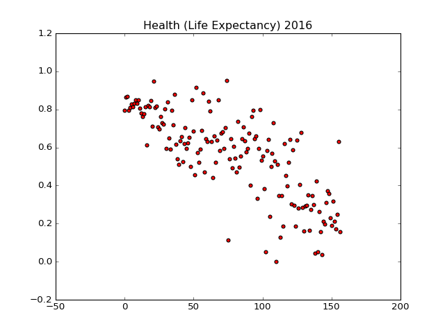

```python
x = range(157)
y = data2016['Health (Life Expectancy)']

plt.figure()
plt.scatter(x, y, c = 'red')
plt.title('Health (Life Expectancy) 2016')
```

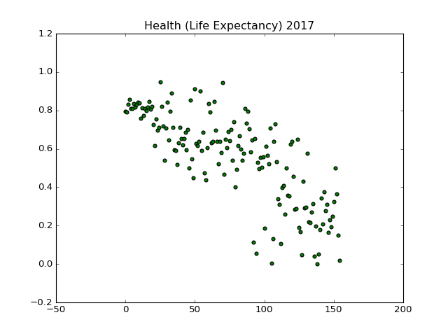

```python
x = range(155)
y = data2017['Health..Life.Expectancy.']
len(y)
plt.figure()
plt.scatter(x, y, c = 'green')
plt.title('Health (Life Expectancy) 2017')
```

## How is the Happiness Score calculated? What is its relation with the other indicators? Can it be derived from the others?

The following is a predictive analysis of the happiness score using the 2015 data.

```python
target = data2015['Happiness Score']
features = data2015.drop(['Country', 'Region', 'Happiness Score', 'Happiness Rank'], axis = 1)
```

```python
target.head()
```

```
Country
Switzerland    7.587
Iceland        7.561
Denmark        7.527
Norway         7.522
Canada         7.427
Name: Happiness Score, dtype: float64
```

```python
features.head()
```

| Country | Standard Error | Economy (GDP per Capita) | Family | Health (Life Expectancy) | Freedom | Trust (Government Corruption) | Generosity | Dystopia Residual |
| --- | --- | --- | --- | --- | --- | --- | --- | --- |
| Switzerland | 0.03411 | 1.39651 | 1.34951 | 0.94143 | 0.66557 | 0.41978 | 0.29678 | 2.51738 |
| Iceland | 0.04884 | 1.30232 | 1.40223 | 0.94784 | 0.62877 | 0.14145 | 0.43630 | 2.70201 |
| Denmark | 0.03328 | 1.32548 | 1.36058 | 0.87464 | 0.64938 | 0.48357 | 0.34139 | 2.49204 |
| Norway | 0.03880 | 1.45900 | 1.33095 | 0.88521 | 0.66973 | 0.36503 | 0.34699 | 2.46531 |
| Canada | 0.03553 | 1.32629 | 1.32261 | 0.90563 | 0.63297 | 0.32957 | 0.45811 | 2.45176 |

```python
import sklearn
from sklearn.model_selection import train_test_split
X_train, X_test, y_train, y_test = train_test_split(features, target, test_size = 0.2, random_state = 0)
```

```python
from sklearn.preprocessing import PolynomialFeatures
poly = PolynomialFeatures(2)
poly.fit_transform(X_train)
poly.transform(X_test);
```

```python
from sklearn.linear_model import Ridge
clf = Ridge(alpha = 1.0)
clf.fit(X_train, y_train)
predictions = clf.predict(X_test)
```

```python
from sklearn.metrics import r2_score
r2_score(y_test, predictions)
```

```
0.99576173512605126
```

Yes, the Happiness Score is readily derivable from the rest of the indicators with a high degree of accuracy.